# Data visualization with ggplot2

## `labs`: Change axis and legend titles and add plot title

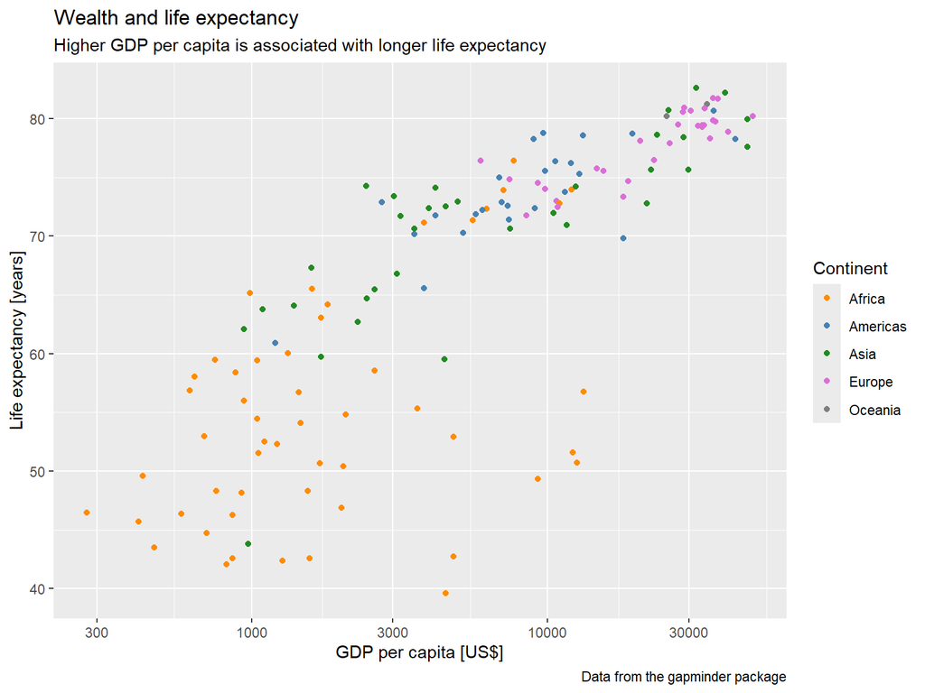

## `theme_*`: change appearance

`ggplot2` offers many pre-defined themes that we can apply to change the appearance of a plot.

```r
my_plot +
  theme_classic()
```

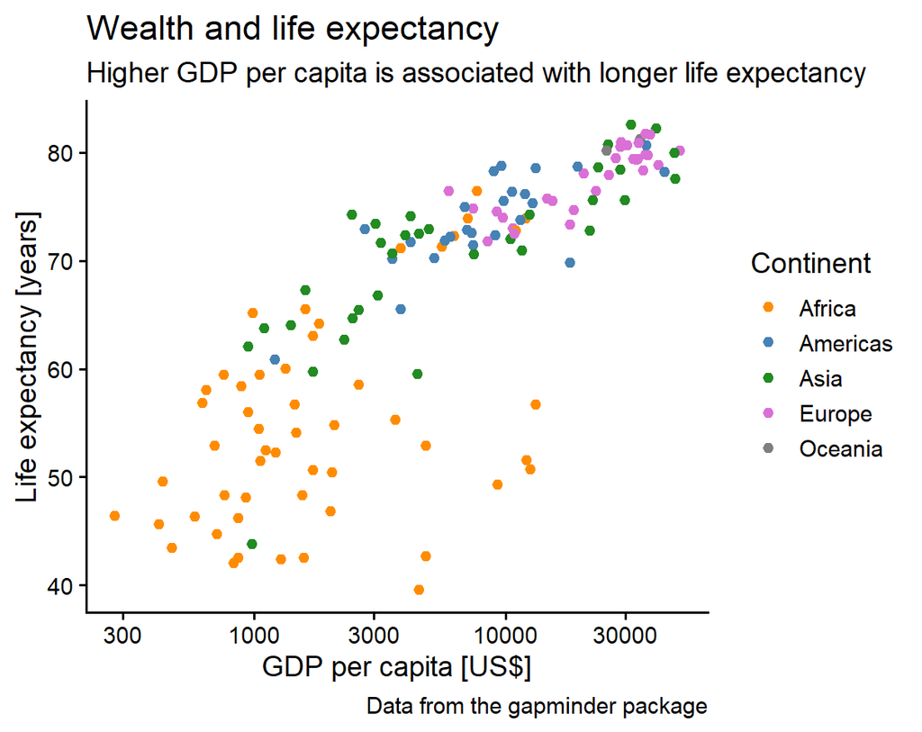

```r
my_plot +
  theme_bw()
```

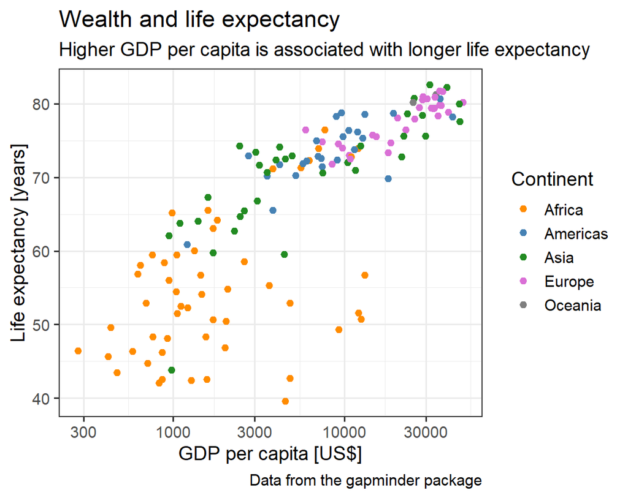

## `theme_*`: change appearance

`ggplot2` offers many pre-defined themes that we can apply to change the appearance of a plot.

```r
my_plot +
  theme_minimal()
```

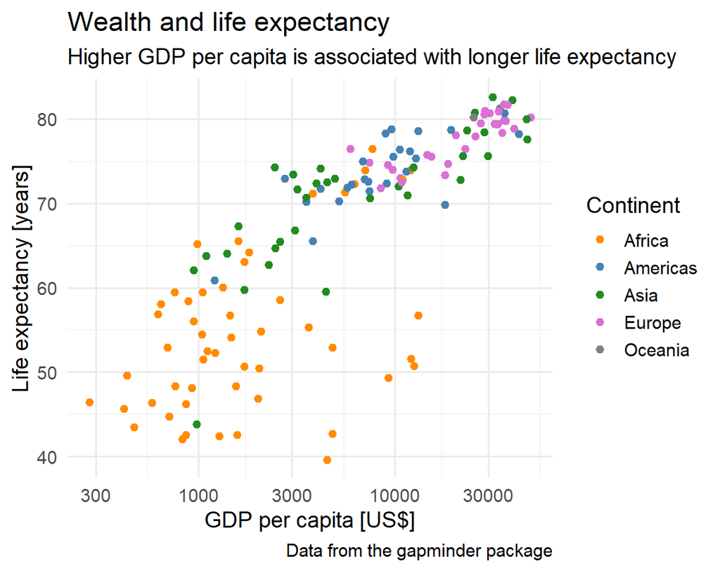

```r
my_plot +
  theme_linedraw()
```

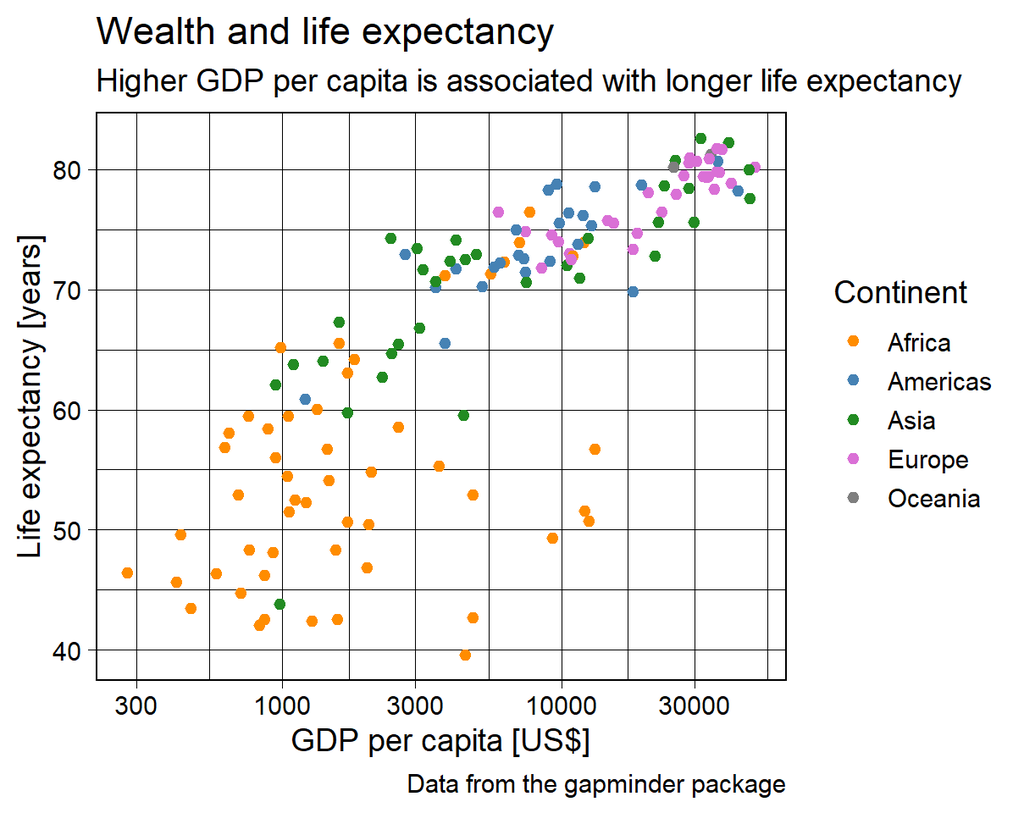

## `theme_*`: change appearance

Since `ggplot2` v. 4.0.0, you can change overall color choices of a pre-defined theme.

```r
my_plot +
  theme_bw(
    ink = "#BBBBBB",
    paper = "#333333"
  )
```

- `paper`: affects background elements
- `ink`: affects foreground elements (text, lines, points, …)
- `accent`: affects elements that are used to highlight information (like `geom_smooth()` lines)

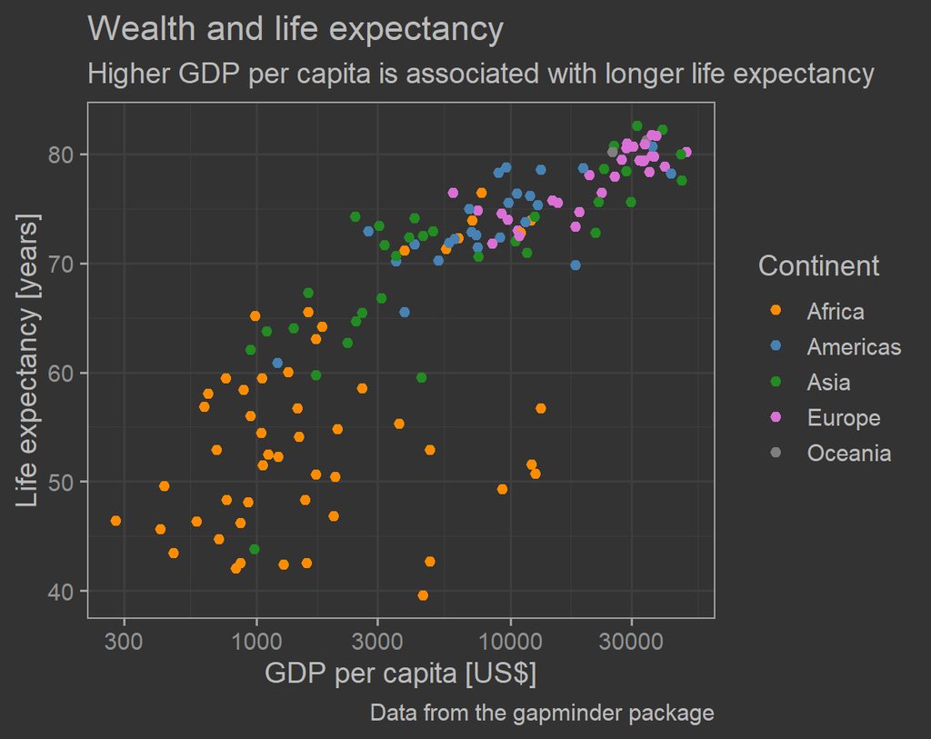

## `theme()`: fine-tune individual elements

```r
my_plot <- my_plot +
  theme_classic() +
  theme(
    # Move legend inside the plot
    legend.position = "inside",
    # Define the position with x and y coordinates (0-1)
    legend.position.inside = c(0.90, 0.2),
    # Make the title bold
    plot.title = element_text(face = "bold"),
    # Make axis titles larger and bold
    axis.title = element_text(size = 14, face = "bold")
  )
my_plot
```

The basic functioning of theme elements is:

```r
theme(
  element_name = element_function()
)
```

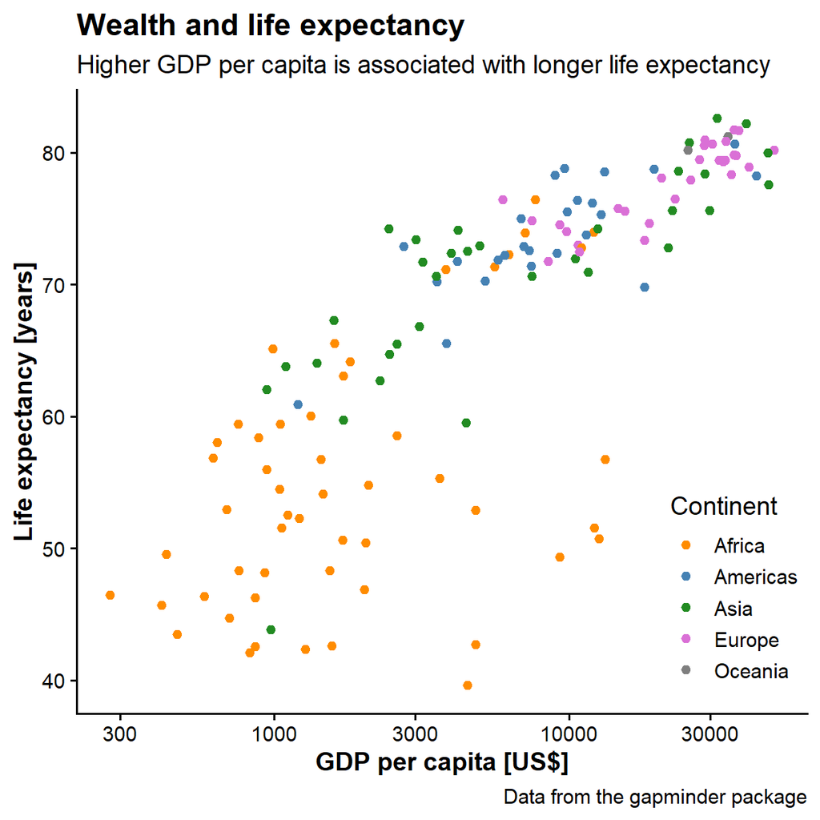

## `theme()`: fine-tune individual elements

- Check `?theme` for all theme elements and options
- Search: “ggplot theme …” (e.my_plot. “ggplot theme remove legend”)

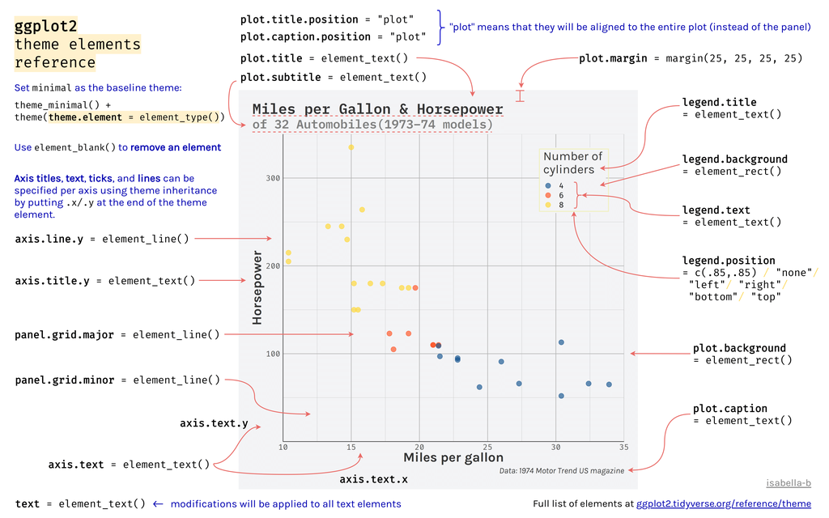

Theme reference sheet by [Isabella Benabaye](https://isabella-b.com/blog/ggplot2-theme-elements-reference/)

## `ggsave()`

A ggplot object can be saved on disk in different formats.

Without specifications:

```r
# save plot my_plot in img as my_plot.pdf
ggsave(filename = "img/my_plot.pdf", plot = my_plot)
# save plot my_plot in img as my_plot.png
ggsave(filename = "img/my_plot.png", plot = my_plot)
```

Or with specifications:

```r
# save a plot named my_plot in the img directory under the name my_plot.png
# with width 16 cm and height 9 cm
ggsave(
  filename = "img/my_plot.png",
  plot = my_plot,
  width = 16,
  heigth = 9,
  units = "cm"
)
```

Have a look at `?ggsave` to see all options.

# Now you

Task 2 (30 min)

Make your penguin plots more beautiful

**Find the task description [here](https://selinazitrone.github.io/intro-r-data-analysis/sessions/tasks/ggplot-task-2.html)**